# act_report

## Report of Insights from the Analysis of tweet archive data

### Introduction

As in the wrangling report, the dataset for this project was from the tweet archive of Twitter user @dog_rates, also known as WeRateDogs. WeRateDogs is a Twitter account that rates people's dogs with a humorous comment about the dog. These ratings almost always have a denominator of 10. The numerators, though almost always greater than 10. 11/10, 12/10, 13/10, etc. WeRateDogs downloaded their Twitter archive and sent it to Udacity via email exclusively for students to use in this project. The following research questions were examined during the analysis and visualization step of the project:

- Research Question 1: What is the average retweet count of the dog breeds from year to year?
- Research Question 2: What is the average favorite count of the dog breeds from year to year?
- Research Question 3: What is the correlation between retweet_count and favorite_count?

### Visualizations and Insights

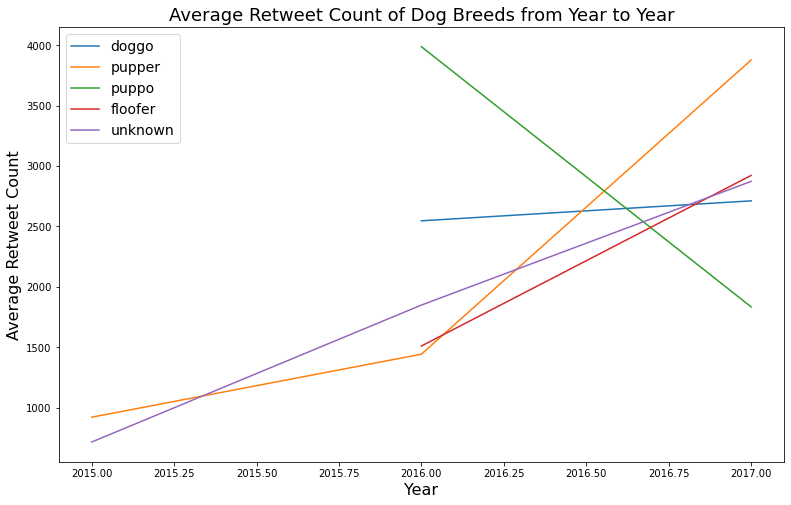

From the graph, it can be seen that:

- for doggo, puppo, and floofer breeds of dogs, the retweet counts began in 2016 whereas for pupper, the retweet count began in 2015.
- The retweet counts for puppo is decreasing with time whereas that for doggo, pupper and floofer are increasing with time.

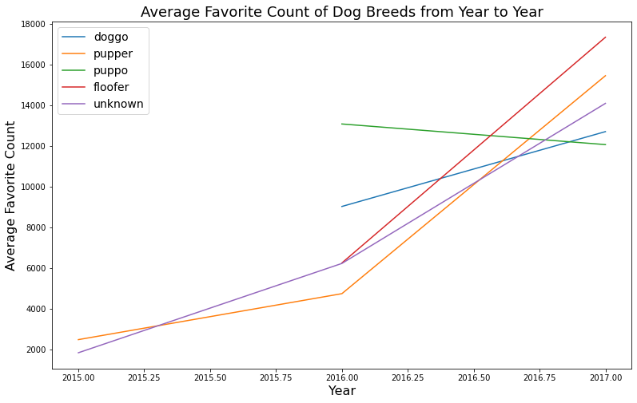

From the graph, it can be seen that:

- like with retweet count, the favorite counts for doggo, puppo and floofer breeds of dogs began in 2016 whereas that for pupper began in 2015.
- The favorite count of puppo is decreasing gradually with time whereas that for doggo, pupper and floofer are increasing.
- It seems pupper and floofer will be the most favorite or popular breeds of dogs over the years.

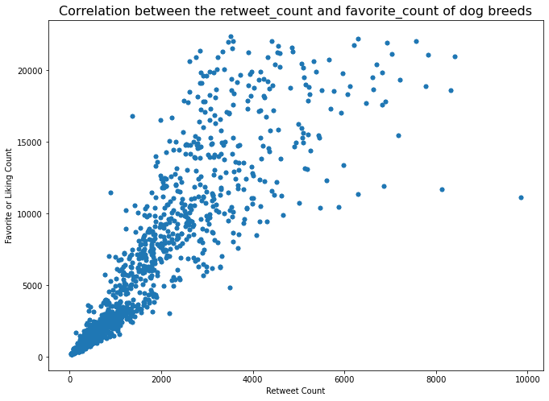

From the scatter plot, it can be seen that:

- There is a positive correlation between retweet_count and favorite_count. That is, when the retweet_count of the dog breeds increases, the favorite_count also increases.
- Since both retweet and favorite counts for pupper and the unknown breed of dogs begin in 2015, and there is a positive correlation between retweet_count and favorite_count, one could substitute pupper for the unknown breed of dogs.